# Decrypt the message.

To decrypt it we have to subtract the key it was given here i present a short way to decrypt it using a library itertools which has a function named cycle, what it does is simply repeat the key as many times as needed

```python
from itertools import cycle
def Encrypt_message(message,key):
    message=message.lower()
    characters='1234567890/-_%?\*.:abcdefghijklmnopqrstuvwxyz!"#$&+@|¨~'
    Encrypt=dict((c, i) for i, c in enumerate(characters))
    Decrypt=dict((i, c) for i, c in enumerate(characters))
    result=""
    for i,j in zip(message,cycle(str(key))):
        result+=Decrypt[Encrypt[i]+int(j)]
    return result
def Decrypt_message(message,key):
    characters='1234567890/-_%?\*.:abcdefghijklmnopqrstuvwxyz!"#$&+@|¨~'
    Encrypt=dict((c, i) for i, c in enumerate(characters))
    Decrypt=dict((i, c) for i, c in enumerate(characters))
    result=""
    for i,j in zip(message,cycle(str(key))):
        result+=Decrypt[Encrypt[i]-int(j)]
    return result
```

In order to show that everybody had a valid url, the solution here presented is using a library called Pandas which is used to read data and work with it as if you wee using Excel. (Don't worry we are going to learn how to use this)

```python
import pandas as pd
pd.set_option('display.max_colwidth', -1)
lista_2=pd.read_csv("../2/Lista_Grupo_2.csv")
lista_2
```

|  | Nombre de usuario | ID de alumno | Llave generada | Mensaje |
| --- | --- | --- | --- | --- |
| 0 | l.alvarezc | 201715912 | 99239575 | q#vs"e.\!jybpn!m$kwvnwjtw#gq#djtvalr"jttw#cqjh.qjkqujyvwrx%pnyvix"%fxrwz#jelxshqn"_pjx!j!a4%uftgmj_ojriijc60huul |
| 1 | n.bahamonn | 201533632 | 16139881 | izus"h:-sgxbpq"ivhvvnzkpozfq#gkpn*kr"mupozbqjk:mbhpuj"wsju_pn"wepy_fxuxvugdlxvimfy-pj!"fs*3%uiuceg-ojujeb:3byvo |
| 2 | ja.baquero | 201717573 | 68331611 | n"wstf--xizbhoui!jxvfxdpt"hquedps:mrtknpt"dqbi-mgjrubzpsow?pfzpeu!?fpsqvziflptbmk!%pbyufx:5%mgncji%obscegb76:voh |
| 3 | ca.barreto | 200814869 | 977316 | q!!stfa.ydxepp!kvh$zluduw!lquelvt%ku"ltrozjuhf-rjivubzxypr_sn!vgpybjvpq!#hjlptjslv-sjz!hs*/.sdnhmh.obskkh\2\hwuj |
| 4 | jf.escobarr | 201718876 | 51769328 | mu!v"c_:wb$eplvpzc"ynuewsult#bewr-qu"howsuhtjf_tfcvxjwqznp:snwqltt:ixpr#ybjoxqctjt.sjvvmw-9*udojib.rjpdlf%90hspo |
| 5 | jj.garzon11 | 201520984 | 55132713 | myusug-%wfxbipukzgvvgydrsyfqvfdrr\krulnrsybqcj-ofgpuc!punt_pg!pgtx_fqtqxyfdlqubojx-pczuhw\3%nhneif-octcgf.4bruh |
| 6 | jc.lopez | 201530171 | 25239879 | jyvs"h.atfybpq!qwgwvnzjxpygq#gjxo\lr"mtxpycqjk.ucgquj"v!kt%pn"vmqx%fxuw$vfelxvhugx_pj!!nt\4%uitkff_ojuimc.4-hxup |
| 7 | m.mejiap | 201713780 | 75683172 | oyzxva._yf#gjj!j"g!!hsjquykvw:jqt\pwvftquygvdd.nhguzduvtpt.uhuvfvx.krnww!fiqrohnlx*udt!gy\8:obtdkf*tdnifh.9/bqui |
| 8 | aj.mendoza | 201716599 | 73386641 | owwxyf?-ydzgmoxi"ex!kxgpuwhvzegpt%mwykqpuwdvgi?mherzgzsspr?ukzsevv?kustv!dfqutemlv%ugyxfy%5:rgqckd%tgsfeh\79evrh |
| 9 | id.montana | 201713874 | 36820620 | kz"rsf_/ug&agovhxh#uexeoqzmpteeop*rqskooqzipai_ldhwtazqrluaoezqdryaeosruwgkkotclhy:oayveu*0_lgobgg:nasddd:93.vpg |
| 10 | sm.morelli | 201713926 | 48193293 | l"uyvba%vixhjk#kyjv"htlrr"fwwalrq:kxvgvrr"bwdeaoejp!dvxumw_vhvxgs!_lroyxxidrrpjoi!-vdu#hv:3aocvehi-udokgeb3?brwj |
| 11 | j.naveros | 201718131 | 68712011 | n"!qu:--xi$:iiui!j"tgrdpt"lov.dps:qpuenpt"hocc-mgjvsctpsow:ngtpeu!:dqmqvzijjqnbmk!.ncsufx:9-nancji.mcmcegb/6apoh |
| 12 | ac.perez1491 | 201127104 | 2896934 | j"#v"c?_zj#hjmvp$h$vitkxt#hrvgluv%nq!nsxqxcvjiaoedw!g#rvkwbsnwsfw".lrqr##gllspiuk"%qc!#k!%6_tjskge_tjskge?00eyqk |
| 13 | js.puerto11 | 201622850 | 27160524 | j!uvse_?thxegnvlwivyewesp!fttdeso.kusjosp!btah_pcipxayqvkv_seyqhqz_iorryvhdooscpgz-saxvit.3*lfoffh-rardhca4\.upk |
| 14 | mp.ramos | 201616928 | 89138820 | p#us!h_/zjxboqvh#kvvmzeov#fq"geouakr!moov#bqik_likpui"qrqx_pm"qdw"_fwuru"jdlwvclm"-pi!veza3%tioblj-oiuddic26gxpg |
| 15 | js.rodriguezp | 201812327 | 32886366 | kv"xyc**uc&gmlznxd#!kuiuqvmvzbiup_rwyhsuqvivgf*rddwzgwuxlqaukwujruakupv!wckquqgrhu:ugvzku_0:rdshgc:tgphjd?9gvqm |
| 16 | ca.ruizm | 201718390 | 76739183 | oz!s"a:%yg$bpj"k"h"vnskruzlq#:krt*qr"furuzhqjd:ohhvujuwupu:pnuwgvy:fxnxx!gjlxoioly.pjt"hy*9%ubuekg.ojnjgh:98hqvj |
| 17 | m.ruiz12 | 201418281 | 61353585 | nuwuve:\xbzdjn"m!cxxhwkttuhswdkts-mtvjuttudsdh:qgcrwdywwop?rhywiut?hrrxzzbfnrsiqkt%rdx"jx-5\ofugjb%qdrjig%57buvl |
| 18 | js.villalba | 201715403 | 21698748 | juzy!g?:tb#hopxpwc!"mygwpukw"fgwo-px!lqwpugwij?tccu!i!szkp.vm!slqt.lwtt#vbirwuetgt*vizxmt-8athqjfb*uitflc%8*gwro |
| 19 | l.wandurraga | 201632471 | 60666456 | ntzvyd\*xa#emmyn!b!ykvhuttktzchus/puyiruttgtgg\rgbuxgxtxoo.skxtjus.iuqu!zaiourfrks*sgwykx/8*rerhja*rgqgjg_70etsm |

so we print the url of the message decrypted in the same order of the list

```python
for i in range(len(lista_2)):
    print(Decrypt_message(lista_2["Mensaje"].iloc[i],lista_2["Llave generada"].iloc[i]))
```

```
https://raw.githubusercontent.com/josemontanac/laboratorio-metodos-computacionales/master/2/lambda/lambda_47.png
https://raw.githubusercontent.com/josemontanac/laboratorio-metodos-computacionales/master/2/lambda/lambda_2.png
https://raw.githubusercontent.com/josemontanac/laboratorio-metodos-computacionales/master/2/lambda/lambda_43.png
https://raw.githubusercontent.com/josemontanac/laboratorio-metodos-computacionales/master/2/lambda/lambda_10.png
https://raw.githubusercontent.com/josemontanac/laboratorio-metodos-computacionales/master/2/lambda/lambda_24.png
https://raw.githubusercontent.com/josemontanac/laboratorio-metodos-computacionales/master/2/lambda/lambda_3.png
https://raw.githubusercontent.com/josemontanac/laboratorio-metodos-computacionales/master/2/lambda/lambda_29.png
https://raw.githubusercontent.com/josemontanac/laboratorio-metodos-computacionales/master/2/lambda/lambda_33.png
https://raw.githubusercontent.com/josemontanac/laboratorio-metodos-computacionales/master/2/lambda/lambda_41.png
https://raw.githubusercontent.com/josemontanac/laboratorio-metodos-computacionales/master/2/lambda/lambda_11.png
https://raw.githubusercontent.com/josemontanac/laboratorio-metodos-computacionales/master/2/lambda/lambda_26.png
https://raw.githubusercontent.com/josemontanac/laboratorio-metodos-computacionales/master/2/lambda/lambda_45.png
https://raw.githubusercontent.com/josemontanac/laboratorio-metodos-computacionales/master/2/lambda/lambda_21.png
https://raw.githubusercontent.com/josemontanac/laboratorio-metodos-computacionales/master/2/lambda/lambda_30.png
https://raw.githubusercontent.com/josemontanac/laboratorio-metodos-computacionales/master/2/lambda/lambda_13.png
https://raw.githubusercontent.com/josemontanac/laboratorio-metodos-computacionales/master/2/lambda/lambda_1.png
https://raw.githubusercontent.com/josemontanac/laboratorio-metodos-computacionales/master/2/lambda/lambda_25.png
https://raw.githubusercontent.com/josemontanac/laboratorio-metodos-computacionales/master/2/lambda/lambda_22.png
https://raw.githubusercontent.com/josemontanac/laboratorio-metodos-computacionales/master/2/lambda/lambda_28.png
https://raw.githubusercontent.com/josemontanac/laboratorio-metodos-computacionales/master/2/lambda/lambda_14.png
```

For the solution with the image it was quite easy to accomplish with the things we saw using numpy here my example is going to be with my image but it can be used for any image

```python
import matplotlib.pyplot as plt
import matplotlib.image as mpimg
import numpy as np
plt.figure(figsize=(10,10))
img=mpimg.imread("https://raw.githubusercontent.com/JoseMontanaC/Laboratorio-Metodos-Computacionales/master/Wigner_2.png")
row,colum,layers=img.shape
plt.imshow(img[:,:,:])
plt.show()
```

[output not shown]

# Squared filter

Here the key to do tis quite fast is with meshgrid as it was indicated but other solutions may work as well

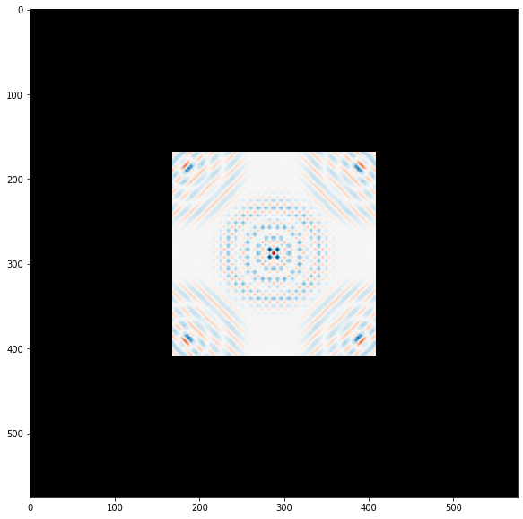

```python
plt.figure(figsize=(10,10))
img=mpimg.imread("https://raw.githubusercontent.com/JoseMontanaC/Laboratorio-Metodos-Computacionales/master/Wigner_2.png")
X,Y = np.meshgrid(range(row),range(colum))
d=120
x_c,y_c=row/2,colum/2 # Define the center of the image (in your case you had to selected by hand)
distance_x=np.abs(X-x_c)
distance_y=np.abs(Y-y_c)
squared_mask=(distance_x>d) + (distance_y>d) # create the numpy filter
img[squared_mask]=0
plt.imshow(img)
plt.show()
```

# (optional) Diamond filter

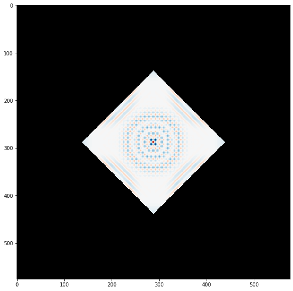

```python
plt.figure(figsize=(10,10))
img=mpimg.imread("https://raw.githubusercontent.com/JoseMontanaC/Laboratorio-Metodos-Computacionales/master/Wigner_2.png")
X,Y = np.meshgrid(range(row),range(colum))
d=150
distance=np.abs((X-x_c))+np.abs(Y-y_c)
Diamond_mask= distance>d
img[Diamond_mask]=0
plt.imshow(img)
plt.show()
```

# The circular filter

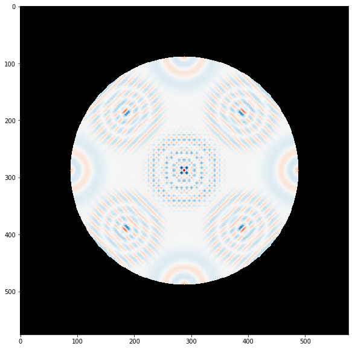

```python
img=mpimg.imread("https://raw.githubusercontent.com/JoseMontanaC/Laboratorio-Metodos-Computacionales/master/Wigner_2.png")
X,Y = np.meshgrid(range(row),range(colum))
R=(200)**2
x_c,y_c=row/2,colum/2

dist_from_center=(X-x_c)**2+(Y-y_c)**2
mask=dist_from_center>R
img[mask]=0
plt.figure(figsize=(10,10))
plt.imshow(img)
plt.show()
```

# Finally the RGB filter

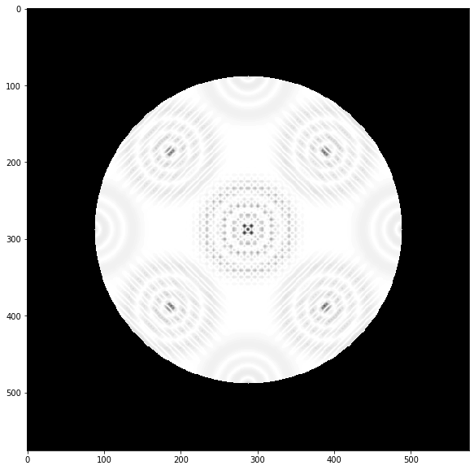

```python
def rgb2gray(rgb):
    r, g, b = rgb[:,:,0], rgb[:,:,1], rgb[:,:,2]
    gray = 0.2989 * r + 0.5870 * g + 0.1140 * b
    return gray
plt.figure(figsize=(10,10))
plt.imshow(rgb2gray(img),cmap="gray")
plt.show()
```

# or if we like to do it for the whole image

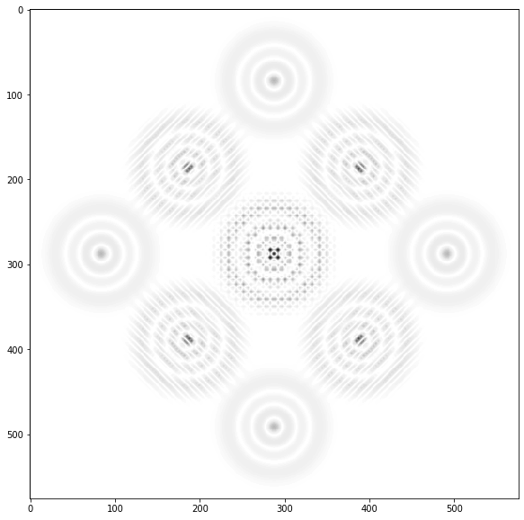

```python
img=mpimg.imread("https://raw.githubusercontent.com/JoseMontanaC/Laboratorio-Metodos-Computacionales/master/Wigner_2.png")
plt.figure(figsize=(10,10))
plt.imshow(rgb2gray(img),cmap="gray")
plt.show()
```